# Week 8 KNN, Ensemble, SVM

## K Nearest Neighbor (KNN)

- Motivations
  - Key ideas: data points closer to each other tend to behave similarly
  - Instance-based learning

## Parameters of KNN

- Number of neighbors (*K*)
  - Too large: high bias
  - Too small: high variance (overfitting)
- Distance functions
  - Euclidean
  - Manhattan
  - Minkowski

## Variance vs. Bias

- Variance: stability of model and predictions
- Bias: accuracy of the model/methodology
- Overfitting: high variance, low bias
- “No Free Lunch” theorem: trade off between variance and bias, no single algorithm will outperform other algorithms on all datasets

## Properties of KNN

- Lazy learner: no active model-building is done with training dataset
  - Vs. active learner
  - No training time, long prediction time. Too slow for an online system.
- Sensitive towards irrelevant attributes
- Sensitive to outliers and noisy data
  - Common property to all distance-based methods
  - Requires data preprocessing: standardization, normalization
- Non-parametric method: no assumption of data distribution
  - Could detect highly complex nonlinear decision boundary

## Demo Dataset: Diabetes

```r
# install.packages("mlbench")
library(caret)
library(mlbench)
data("PimaIndiansDiabetes")
diabetes <- PimaIndiansDiabetes
str(diabetes)
```

```
## 'data.frame':    768 obs. of  9 variables:
##  $ pregnant: num  6 1 8 1 0 5 3 10 2 8 ...
##  $ glucose : num  148 85 183 89 137 116 78 115 197 125 ...
##  $ pressure: num  72 66 64 66 40 74 50 0 70 96 ...
##  $ triceps : num  35 29 0 23 35 0 32 0 45 0 ...
##  $ insulin : num  0 0 0 94 168 0 88 0 543 0 ...
##  $ mass    : num  33.6 26.6 23.3 28.1 43.1 25.6 31 35.3 30.5 0 ...
##  $ pedigree: num  0.627 0.351 0.672 0.167 2.288 ...
##  $ age     : num  50 31 32 21 33 30 26 29 53 54 ...
##  $ diabetes: Factor w/ 2 levels "neg","pos": 2 1 2 1 2 1 2 1 2 2 ...
```

```r
summary(diabetes)
```

```
##     pregnant         glucose         pressure         triceps
##  Min.   : 0.000   Min.   :  0.0   Min.   :  0.00   Min.   : 0.00
##  1st Qu.: 1.000   1st Qu.: 99.0   1st Qu.: 62.00   1st Qu.: 0.00
##  Median : 3.000   Median :117.0   Median : 72.00   Median :23.00
##  Mean   : 3.845   Mean   :120.9   Mean   : 69.11   Mean   :20.54
##  3rd Qu.: 6.000   3rd Qu.:140.2   3rd Qu.: 80.00   3rd Qu.:32.00
##  Max.   :17.000   Max.   :199.0   Max.   :122.00   Max.   :99.00
##     insulin           mass          pedigree           age
##  Min.   :  0.0   Min.   : 0.00   Min.   :0.0780   Min.   :21.00
##  1st Qu.:  0.0   1st Qu.:27.30   1st Qu.:0.2437   1st Qu.:24.00
##  Median : 30.5   Median :32.00   Median :0.3725   Median :29.00
##  Mean   : 79.8   Mean   :31.99   Mean   :0.4719   Mean   :33.24
##  3rd Qu.:127.2   3rd Qu.:36.60   3rd Qu.:0.6262   3rd Qu.:41.00
##  Max.   :846.0   Max.   :67.10   Max.   :2.4200   Max.   :81.00
##  diabetes
##  neg:500
##  pos:268
##
##
##
##
```

## Train and Test Baseline KNN Model

```r
library(caret)

set.seed(188)
train_index <- createDataPartition(diabetes$diabetes, p = 0.7, list = FALSE)

diabetes_train <- diabetes[train_index, ]
diabetes_test <- diabetes[-train_index, ]


model_knn <- train(diabetes ~ ., data = diabetes_train, method = "knn")
predict_knn <- predict(model_knn, newdata = diabetes_test)
```

## Measure Model Performance: Hold-Out Method

```r
confusionMatrix(predict_knn, diabetes_test$diabetes)
```

```
## Confusion Matrix and Statistics
##
##           Reference
## Prediction neg pos
##        neg 126  36
##        pos  24  44
##
##                Accuracy : 0.7391
##                  95% CI : (0.6773, 0.7946)
##     No Information Rate : 0.6522
##     P-Value [Acc > NIR] : 0.002949
##
##                   Kappa : 0.4041
##  Mcnemar's Test P-Value : 0.155580
##
##             Sensitivity : 0.8400
##             Specificity : 0.5500
##          Pos Pred Value : 0.7778
##          Neg Pred Value : 0.6471
##              Prevalence : 0.6522
##          Detection Rate : 0.5478
##    Detection Prevalence : 0.7043
##       Balanced Accuracy : 0.6950
##
##        'Positive' Class : neg
##
```

## Measure Model Performance: Bootstrap Method

```r
print(model_knn)
```

```
## k-Nearest Neighbors
##
## 538 samples
##   8 predictor
##   2 classes: 'neg', 'pos'
##
## No pre-processing
## Resampling: Bootstrapped (25 reps)
## Summary of sample sizes: 538, 538, 538, 538, 538, 538, ...
## Resampling results across tuning parameters:
##
##   k  Accuracy   Kappa
##   5  0.6901734  0.3082508
##   7  0.6989885  0.3185598
##   9  0.7121062  0.3449934
##
## Accuracy was used to select the optimal model using the largest value.
## The final value used for the model was k = 9.
```

## Pre-process Data

```r
pre_process <- preProcess(diabetes_train, method = c("scale", "center"))
pre_process
```

```
## Created from 538 samples and 9 variables
##
## Pre-processing:
##   - centered (8)
##   - ignored (1)
##   - scaled (8)
```

```r
diabetes_train1 <- predict(pre_process, newdata = diabetes_train)
diabetes_test1 <- predict(pre_process, newdata = diabetes_test)
summary(diabetes_train1)
```

```
##     pregnant          glucose           pressure           triceps
##  Min.   :-1.1089   Min.   :-3.7915   Min.   :-3.61879   Min.   :-1.2893
##  1st Qu.:-0.8243   1st Qu.:-0.6594   1st Qu.:-0.36502   1st Qu.:-1.2893
##  Median :-0.2550   Median :-0.1270   Median : 0.05482   Median : 0.1813
##  Mean   : 0.0000   Mean   : 0.0000   Mean   : 0.00000   Mean   : 0.0000
##  3rd Qu.: 0.5989   3rd Qu.: 0.6169   3rd Qu.: 0.47466   3rd Qu.: 0.7328
##  Max.   : 3.7299   Max.   : 2.4414   Max.   : 2.78379   Max.   : 4.7771
##     insulin             mass              pedigree            age
##  Min.   :-0.6787   Min.   :-4.146198   Min.   :-1.1951   Min.   :-1.0365
##  1st Qu.:-0.6787   1st Qu.:-0.605945   1st Qu.:-0.7106   1st Qu.:-0.7809
##  Median :-0.5087   Median : 0.009751   Median :-0.2590   Median :-0.3549
##  Mean   : 0.0000   Mean   : 0.000000   Mean   : 0.0000   Mean   : 0.0000
##  3rd Qu.: 0.4158   3rd Qu.: 0.596587   3rd Qu.: 0.4550   3rd Qu.: 0.6675
##  Max.   : 6.5131   Max.   : 4.460722   Max.   : 5.8088   Max.   : 4.0755
##  diabetes
##  neg:350
##  pos:188
##
##
##
##
```

```r
summary(diabetes_test1)
```

```
##     pregnant           glucose            pressure          triceps
##  Min.   :-1.10892   Min.   :-3.79153   Min.   :-3.6188   Min.   :-1.2893
##  1st Qu.:-0.82428   1st Qu.:-0.72207   1st Qu.:-0.2601   1st Qu.:-1.2893
##  Median :-0.25501   Median :-0.07999   Median : 0.1598   Median :-0.1251
##  Mean   :-0.04834   Mean   :-0.01667   Mean   : 0.0263   Mean   :-0.1032
##  3rd Qu.: 0.31426   3rd Qu.: 0.55426   3rd Qu.: 0.5796   3rd Qu.: 0.6562
##  Max.   : 2.59135   Max.   : 2.37871   Max.   : 2.1540   Max.   : 1.7745
##     insulin               mass            pedigree
##  Min.   :-0.678722   Min.   :-4.1462   Min.   :-1.17414
##  1st Qu.:-0.678722   1st Qu.:-0.7791   1st Qu.:-0.68668
##  Median :-0.300427   Median :-0.1442   Median :-0.39959
##  Mean   :-0.001154   Mean   :-0.1419   Mean   :-0.05735
##  3rd Qu.: 0.354151   3rd Qu.: 0.4074   3rd Qu.: 0.36673
##  Max.   : 4.243363   Max.   : 2.9087   Max.   : 5.41402
##       age           diabetes
##  Min.   :-1.03648   neg:150
##  1st Qu.:-0.78089   pos: 80
##  Median :-0.31229
##  Mean   : 0.02147
##  3rd Qu.: 0.58230
##  Max.   : 3.13827
```

```r
names(pre_process)
```

```
##  [1] "dim"               "bc"                "yj"
##  [4] "et"                "invHyperbolicSine" "mean"
##  [7] "std"               "ranges"            "rotation"
## [10] "method"            "thresh"            "pcaComp"
## [13] "numComp"           "ica"               "wildcards"
## [16] "k"                 "knnSummary"        "bagImp"
## [19] "median"            "data"              "rangeBounds"
```

```r
typeof(pre_process)
```

```
## [1] "list"
```

```r
str(pre_process)
```

```
## List of 21
##  $ dim              : int [1:2] 538 9
##  $ bc               : NULL
##  $ yj               : NULL
##  $ et               : NULL
##  $ invHyperbolicSine: NULL
##  $ mean             : Named num [1:8] 3.9 121.1 69 21 79.8 ...
##   ..- attr(*, "names")= chr [1:8] "pregnant" "glucose" "pressure" "triceps" ...
##  $ std              : Named num [1:8] 3.51 31.93 19.05 16.32 117.63 ...
##   ..- attr(*, "names")= chr [1:8] "pregnant" "glucose" "pressure" "triceps" ...
##  $ ranges           : NULL
##  $ rotation         : NULL
##  $ method           :List of 3
##   ..$ scale : chr [1:8] "pregnant" "glucose" "pressure" "triceps" ...
##   ..$ center: chr [1:8] "pregnant" "glucose" "pressure" "triceps" ...
##   ..$ ignore: chr "diabetes"
##  $ thresh           : num 0.95
##  $ pcaComp          : NULL
##  $ numComp          : NULL
##  $ ica              : NULL
##  $ wildcards        :List of 2
##   ..$ PCA: chr(0)
##   ..$ ICA: chr(0)
##  $ k                : num 5
##  $ knnSummary       :function (x, ...)
##  $ bagImp           : NULL
##  $ median           : NULL
##  $ data             : NULL
##  $ rangeBounds      : num [1:2] 0 1
##  - attr(*, "class")= chr "preProcess"
```

```r
pre_process$method$scale[1]
```

```
## [1] "pregnant"
```

```r
set.seed(188)
diabetes1 <- predict(pre_process, diabetes)
summary(diabetes1)
```

```
##     pregnant           glucose             pressure
##  Min.   :-1.10892   Min.   :-3.791531   Min.   :-3.618793
##  1st Qu.:-0.82428   1st Qu.:-0.690751   1st Qu.:-0.365020
##  Median :-0.25501   Median :-0.126972   Median : 0.159782
##  Mean   :-0.01448   Mean   :-0.004992   Mean   : 0.007876
##  3rd Qu.: 0.59890   3rd Qu.: 0.601241   3rd Qu.: 0.579623
##  Max.   : 3.72990   Max.   : 2.441351   Max.   : 2.783792
##     triceps            insulin               mass
##  Min.   :-1.28931   Min.   :-0.678722   Min.   :-4.14620
##  1st Qu.:-1.28931   1st Qu.:-0.678722   1st Qu.:-0.64443
##  Median : 0.12005   Median :-0.419441   Median :-0.04156
##  Mean   :-0.03091   Mean   :-0.000346   Mean   :-0.04251
##  3rd Qu.: 0.67153   3rd Qu.: 0.403032   3rd Qu.: 0.54849
##  Max.   : 4.77705   Max.   : 6.513133   Max.   : 4.46072
##     pedigree             age            diabetes
##  Min.   :-1.19508   Min.   :-1.036484   neg:500
##  1st Qu.:-0.69939   1st Qu.:-0.780886   pos:268
##  Median :-0.31436   Median :-0.354891
##  Mean   :-0.01717   Mean   : 0.006429
##  3rd Qu.: 0.44449   3rd Qu.: 0.667499
##  Max.   : 5.80877   Max.   : 4.075463
```

```r
train_index1 <- createDataPartition(diabetes1$diabetes, p = 0.7, list = FALSE)

diabetes_train1 <- diabetes1[train_index1, ]
diabetes_test1 <- diabetes1[-train_index1, ]
```

## New Model Using Standardized Dataset

```r
model_knn1 <- train(diabetes ~ ., data = diabetes_train1, method = "knn")
predict_knn1 <- predict(model_knn1, newdata = diabetes_test1)

confusionMatrix(predict_knn1, diabetes_test1$diabetes, positive = "pos")
```

```
## Confusion Matrix and Statistics
##
##           Reference
## Prediction neg pos
##        neg 128  40
##        pos  22  40
##
##                Accuracy : 0.7304
##                  95% CI : (0.6682, 0.7866)
##     No Information Rate : 0.6522
##     P-Value [Acc > NIR] : 0.006878
##
##                   Kappa : 0.3729
##  Mcnemar's Test P-Value : 0.030850
##
##             Sensitivity : 0.5000
##             Specificity : 0.8533
##          Pos Pred Value : 0.6452
##          Neg Pred Value : 0.7619
##              Prevalence : 0.3478
##          Detection Rate : 0.1739
##    Detection Prevalence : 0.2696
##       Balanced Accuracy : 0.6767
##
##        'Positive' Class : pos
##
```

## Tune the KNN Model

```r
model_knn2 <- train(diabetes ~ ., data = diabetes_train1, method = "knn",
                    tuneGrid = data.frame(k = seq(1, 25)),
                    trControl = trainControl(method = "repeatedcv",
                                             number = 10, repeats = 3))
print(model_knn2)
```

```
## k-Nearest Neighbors
##
## 538 samples
##   8 predictor
##   2 classes: 'neg', 'pos'
##
## No pre-processing
## Resampling: Cross-Validated (10 fold, repeated 3 times)
## Summary of sample sizes: 484, 484, 485, 484, 484, 484, ...
## Resampling results across tuning parameters:
##
##   k   Accuracy   Kappa
##    1  0.7286862  0.3978076
##    2  0.7094107  0.3529792
##    3  0.7336711  0.4001536
```

[output cut: 25 more lines]

## Sensitivity Analysis of KNN

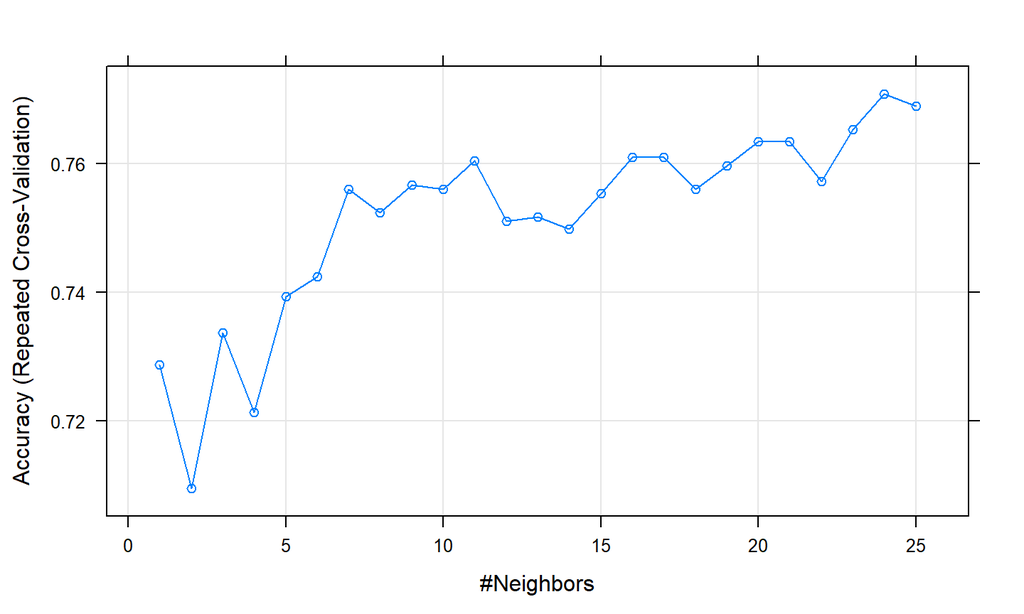

```r
plot(model_knn2)
```

## Ensemble Learning Motivations

- Combine multiple classifiers together and take consensus
- Different mechanisms to produce multiple classifiers from the same datasets
  - Bagging (Bootstrap Aggregation): create multiple samples (with replacement) from the original dataset and train multiple classifiers; reduce variance
  - Boosting: an iterative algorithm that assigns different weights to the data points to focus on those tougher cases: reduce bias
  - Random Forest: train large number of decision stumps (smaller decision trees with less nodes) and use committee majority voting to decide the final classification

## Model Parameters

- learning rate
- depth of trees
- mtry for random forest: optional integer for number of features to randomly select at each split
- ntree: number of classifiers

## Algorithms: Random Forest

- Produce a distribution of simple ML models on subsets of the original data
- Combine the distribution into one “aggregated” model
- Train
  1. Pick \(k\) features from the dataset with \(m\) features (\(k \ll m\))
  2. Among \(k\) features, pick the one that maximize information gain (or gain ratio) and use it as the node to further split the data
  3. Repeat step 2 to derive individual decision tree
  4. Repeat step 1 - 3 to generate \(n\) number of trees
- Predict
  1. Apply each individual tree from the \(n\) random trees to the test data point and derive the outcomes and store the \(n\) predicted outcome
  2. Calculate the weight for each predicted oucome
  3. Consider the outcome with the highest weight as the final classication/prediction for the test data point

## Property of the Algorithms: Pros and Cons

- Pros
  - Perform well on a wide variety of tasks
  - Some ensemble methods such as random forest are robust to overfitting
- Cons
  - Interpretability issue
  - Might be sensitive to outliers: boosting
  - Higher computational cost

## Bagging: Training

```r
model_bag <- train(diabetes ~ ., data = diabetes_train1, method = "treebag")
model_bag
```

```
## Bagged CART
##
## 538 samples
##   8 predictor
##   2 classes: 'neg', 'pos'
##
## No pre-processing
## Resampling: Bootstrapped (25 reps)
## Summary of sample sizes: 538, 538, 538, 538, 538, 538, ...
## Resampling results:
##
##   Accuracy   Kappa
##   0.7500153  0.4393192
```

## Bagging: Prediction and Performance Evaluation

```r
predict_bag <- predict(model_bag, newdata = diabetes_test1)
confusionMatrix(predict_bag, diabetes_test1$diabetes)
```

```
## Confusion Matrix and Statistics
##
##           Reference
## Prediction neg pos
##        neg 121  32
##        pos  29  48
##
##                Accuracy : 0.7348
##                  95% CI : (0.6728, 0.7906)
##     No Information Rate : 0.6522
##     P-Value [Acc > NIR] : 0.004551
##
##                   Kappa : 0.4103
##  Mcnemar's Test P-Value : 0.797894
##
##             Sensitivity : 0.8067
##             Specificity : 0.6000
##          Pos Pred Value : 0.7908
##          Neg Pred Value : 0.6234
##              Prevalence : 0.6522
##          Detection Rate : 0.5261
##    Detection Prevalence : 0.6652
##       Balanced Accuracy : 0.7033
##
##        'Positive' Class : neg
##
```

## Random Forest

```r
model_rf <- train(diabetes ~ ., data = diabetes_train1, method = "rf")
model_rf
```

```
## Random Forest
##
## 538 samples
##   8 predictor
##   2 classes: 'neg', 'pos'
##
## No pre-processing
## Resampling: Bootstrapped (25 reps)
## Summary of sample sizes: 538, 538, 538, 538, 538, 538, ...
## Resampling results across tuning parameters:
##
##   mtry  Accuracy   Kappa
##   2     0.7549117  0.4452040
##   5     0.7467680  0.4324403
##   8     0.7380203  0.4113337
##
## Accuracy was used to select the optimal model using the largest value.
## The final value used for the model was mtry = 2.
```

## Check the Importance of Attributes

```r
varimp_rf <- varImp(model_rf)
varimp_rf
```

```
## rf variable importance
##
##          Overall
## glucose  100.000
## mass      54.073
## age       46.932
## pedigree  29.680
## pregnant  11.286
## pressure  10.882
## insulin    1.039
## triceps    0.000
```

## Visualize the Attributes’ Importance

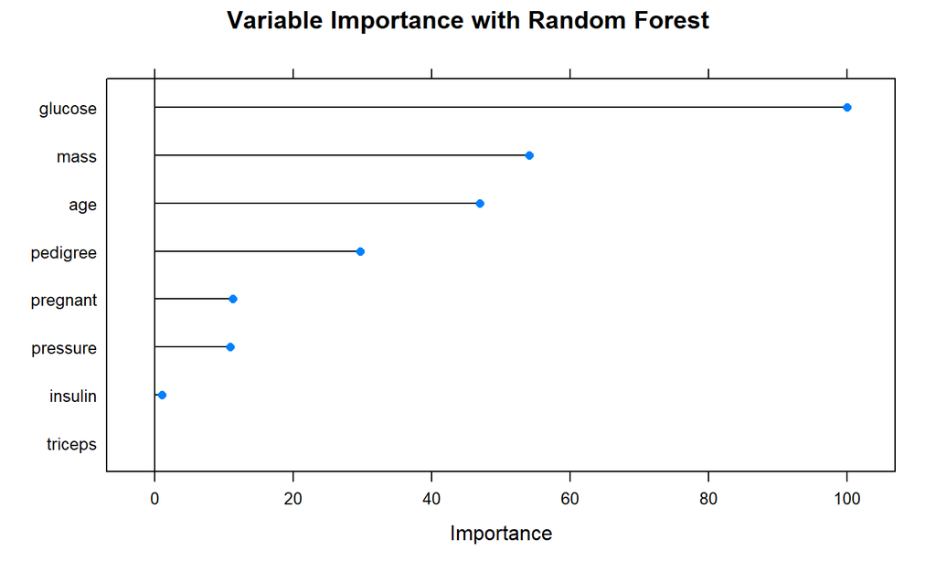

```r
plot(varimp_rf, main = "Variable Importance with Random Forest")
```

## Support Vector Machine (SVM) Motivations

- Work with both linearly separable and linearly non-separable cases
- Maximize margin between categories
- Margins are only decided by the closest data points (support vectors)
  - SVM is robust for the outliers
  - Distance between data points and decision boundary indicates confidence of prediction

## Kernel Tricks

- Deal with classification that requires multiple (and nonlinear boundaries)
- Ideas: apply mathematical functions (kernels) to project linearly unseparable data points into higher dimensional space so that a hyperplane could be found to separate different classes
- Non-linear kernels
  - Radial basis function (RBF) \[ K(X_m, X_n) = exp(-\frac{||X_m - X_n||^2}{2\sigma^2}) \]
  - Polynomial kernel \[ K(X_m, x_n) = (X_mX_n + c)^d \]
  - Sigmoid kernel \[ K(X_m, X_n) = tanh(\kappaX_mX_n-\delta) \]

## Model Parameters

- C (Cost): used for regularization, penalty associated with misclassification
  - Soft margin classification: allow a small numbr of misclassifications
  - Hyperparameter controling penalizing use of slack variables \(\xi\)
  - Higher C, lower bias but risk of overfitting; higher complexiity of decision boundary; higher number of support vectors
  - Lower C, higher bias but lower variance
- Kernel function specific parameters
  - \(\gamma\) for RBF: contols the tradeoff between error due to bias and variance
    - \(k(X_m, X_n) = exp(-\gamma||X_m-X_n||^2)\)
    - Higher \(\gamma\) means higher risk of overfitting; lower \(\gamma\) means higher bias; moves in the same direction as C
  - Degree for Polynomial kernel
  - Scale for Polynomial kernel

## Properties of SVM

- Pros
  - Excellent performance for a wide variety of tasks because it can deal with nonlinear decision boundary
  - Provide confidence estimate (probability transformed from distance by properly mathematics functions)
  - Robust to noisy data
  - Flexible with data representation: numerical and categorical attributes
- Cons
  - Lack of interpretability. Black-box model
  - Risk of choosing wrong kernel function

## Demo: Train a Linear SVM Model

```r
set.seed(1818)
model_svm_linear <- train(diabetes ~ ., data = diabetes_train,
                          method = "svmLinear",
                          preProcess = c("center", "scale"),
                          trControl = trainControl(method = "boot", number = 25),
                          tuneGrid = expand.grid(C = seq(0, 1, 0.05)))
model_svm_linear
```

```
## Support Vector Machines with Linear Kernel
##
## 538 samples
##   8 predictor
##   2 classes: 'neg', 'pos'
##
## Pre-processing: centered (8), scaled (8)
## Resampling: Bootstrapped (25 reps)
## Summary of sample sizes: 538, 538, 538, 538, 538, 538, ...
## Resampling results across tuning parameters:
##
##   C     Accuracy   Kappa
##   0.00        NaN        NaN
##   0.05  0.7617913  0.4563736
##   0.10  0.7600813  0.4535191
##   0.15  0.7605774  0.4547414
##   0.20  0.7603933  0.4547595
##   0.25  0.7608005  0.4555370
##   0.30  0.7602058  0.4542325
##   0.35  0.7606215  0.4553087
##   0.40  0.7608251  0.4558617
##   0.45  0.7614284  0.4571489
##   0.50  0.7616284  0.4575390
##   0.55  0.7612264  0.4567524
##   0.60  0.7614284  0.4572411
##   0.65  0.7612264  0.4567524
##   0.70  0.7616284  0.4576311
##   0.75  0.7614264  0.4571425
##   0.80  0.7614361  0.4572523
##   0.85  0.7614264  0.4571425
##   0.90  0.7614264  0.4571425
##   0.95  0.7618265  0.4582616
##   1.00  0.7616043  0.4578212
##
## Accuracy was used to select the optimal model using the largest value.
## The final value used for the model was C = 0.95.
```

## Sensitivity Test for C

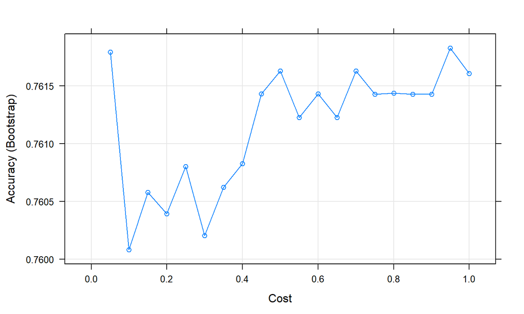

```r
plot(model_svm_linear)
```

## Linear SVM Performance Evaluation: Hold-out Method

```r
predict_svm_linear <- predict(model_svm_linear, newdata = diabetes_test)
confusionMatrix(predict_svm_linear, diabetes_test$diabetes)
```

```
## Confusion Matrix and Statistics
##
##           Reference
## Prediction neg pos
##        neg 134  36
##        pos  16  44
##
##                Accuracy : 0.7739
##                  95% CI : (0.7143, 0.8263)
##     No Information Rate : 0.6522
##     P-Value [Acc > NIR] : 4.208e-05
##
##                   Kappa : 0.4708
##  Mcnemar's Test P-Value : 0.008418
##
##             Sensitivity : 0.8933
##             Specificity : 0.5500
##          Pos Pred Value : 0.7882
##          Neg Pred Value : 0.7333
##              Prevalence : 0.6522
##          Detection Rate : 0.5826
##    Detection Prevalence : 0.7391
##       Balanced Accuracy : 0.7217
##
##        'Positive' Class : neg
##
```

## SVM with Non-linear Kernel: RBF

```r
model_svm_rbf <- train(diabetes ~ ., data = diabetes_train,
                       preProcess = c("center", "scale"),
                       tuneGrid = expand.grid(sigma = seq(0, 1, 0.1),
                                              C = seq(0, 1, 0.1)),
                       method = "svmRadial",
                       trControl = trainControl(method = "boot",
                                                number = 25))
```

```r
model_svm_rbf
```

```
## Support Vector Machines with Radial Basis Function Kernel
##
## 538 samples
##   8 predictor
##   2 classes: 'neg', 'pos'
##
## Pre-processing: centered (8), scaled (8)
## Resampling: Bootstrapped (25 reps)
## Summary of sample sizes: 538, 538, 538, 538, 538, 538, ...
## Resampling results across tuning parameters:
##
##   sigma  C    Accuracy   Kappa
##   0.0    0.0        NaN          NaN
##   0.0    0.1  0.6512478  0.000000000
##   0.0    0.2  0.6512478  0.000000000
##   0.0    0.3  0.6512478  0.000000000
##   0.0    0.4  0.6512478  0.000000000
##   0.0    0.5  0.6512478  0.000000000
##   0.0    0.6  0.6512478  0.000000000
##   0.0    0.7  0.6512478  0.000000000
##   0.0    0.8  0.6512478  0.000000000
##   0.0    0.9  0.6512478  0.000000000
##   0.0    1.0  0.6512478  0.000000000
##   0.1    0.0        NaN          NaN
##   0.1    0.1  0.7418882  0.356733112
##   0.1    0.2  0.7557221  0.417026383
##   0.1    0.3  0.7624871  0.441724027
##   0.1    0.4  0.7637365  0.447354762
##   0.1    0.5  0.7654968  0.452818008
##   0.1    0.6  0.7650638  0.453125832
##   0.1    0.7  0.7622742  0.448298608
##   0.1    0.8  0.7621327  0.449610338
##   0.1    0.9  0.7613368  0.449319274
##   0.1    1.0  0.7627733  0.453799274
##   0.2    0.0        NaN          NaN
##   0.2    0.1  0.7113016  0.240653384
##   0.2    0.2  0.7468655  0.386740621
##   0.2    0.3  0.7563845  0.422211842
##   0.2    0.4  0.7561906  0.427432365
##   0.2    0.5  0.7574452  0.434697605
```

[output cut: 81 more lines]

```
##   0.9    1.0  0.6935090  0.256805473
##   1.0    0.0        NaN          NaN
##   1.0    0.1  0.6512478  0.000000000
##   1.0    0.2  0.6534984  0.008371326
##   1.0    0.3  0.6561128  0.025257001
##   1.0    0.4  0.6587495  0.054359290
##   1.0    0.5  0.6653984  0.104219906
##   1.0    0.6  0.6686840  0.138038790
##   1.0    0.7  0.6695507  0.153397306
##   1.0    0.8  0.6734856  0.172778719
##   1.0    0.9  0.6785749  0.195043725
##   1.0    1.0  0.6804877  0.210732340
##
## Accuracy was used to select the optimal model using the largest value.
## The final values used for the model were sigma = 0.1 and C = 0.5.
```

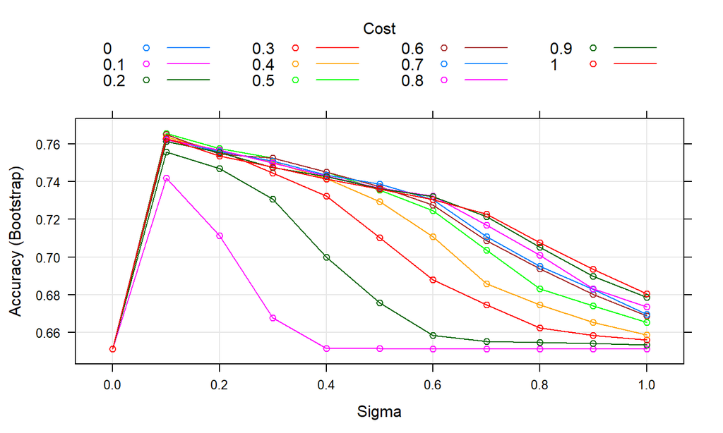

```r
plot(model_svm_rbf)
```

```r
predict_svm_rbf <- predict(model_svm_rbf, newdata = diabetes_test)
confusionMatrix(predict_svm_rbf, diabetes_test$diabetes)
```

```
## Confusion Matrix and Statistics
##
##           Reference
## Prediction neg pos
##        neg 131  43
##        pos  19  37
##
##                Accuracy : 0.7304
##                  95% CI : (0.6682, 0.7866)
##     No Information Rate : 0.6522
##     P-Value [Acc > NIR] : 0.006878
##
##                   Kappa : 0.3611
##  Mcnemar's Test P-Value : 0.003489
##
##             Sensitivity : 0.8733
##             Specificity : 0.4625
##          Pos Pred Value : 0.7529
##          Neg Pred Value : 0.6607
##              Prevalence : 0.6522
##          Detection Rate : 0.5696
##    Detection Prevalence : 0.7565
##       Balanced Accuracy : 0.6679
##
##        'Positive' Class : neg
##
```

## Compare the Performance of Multiple Algorithms

```r
model_comparison <- resamples(list(RF = model_rf, BAG = model_bag, SVMLinear = model_svm_linear,
                                   SVMRBF = model_svm_rbf, KNN = model_knn))
summary(model_comparison)
```

```
##
## Call:
## summary.resamples(object = model_comparison)
##
## Models: RF, BAG, SVMLinear, SVMRBF, KNN
## Number of resamples: 25
##
## Accuracy
##                Min.   1st Qu.    Median      Mean   3rd Qu.      Max. NA's
## RF        0.7171717 0.7379679 0.7500000 0.7549117 0.7688442 0.8229167    0
## BAG       0.7040816 0.7382199 0.7437186 0.7500153 0.7626263 0.7931034    0
## SVMLinear 0.6969697 0.7371134 0.7638191 0.7618265 0.7839196 0.8125000    0
## SVMRBF    0.7315789 0.7526316 0.7656250 0.7654968 0.7766497 0.8031088    0
## KNN       0.6153846 0.6887755 0.7168950 0.7121062 0.7433155 0.7817259    0
##
## Kappa
##                Min.   1st Qu.    Median      Mean   3rd Qu.      Max. NA's
## RF        0.3562471 0.4201021 0.4363992 0.4452040 0.4825325 0.5577236    0
## BAG       0.3601981 0.4076349 0.4402985 0.4393192 0.4751578 0.5247492    0
## SVMLinear 0.3432836 0.4134789 0.4659401 0.4582616 0.4931610 0.5637772    0
## SVMRBF    0.3760464 0.4141189 0.4633530 0.4528180 0.4885286 0.5365331    0
## KNN       0.1355872 0.2960546 0.3634009 0.3449934 0.4008293 0.4835935    0
```

## Graphically Compare Performance

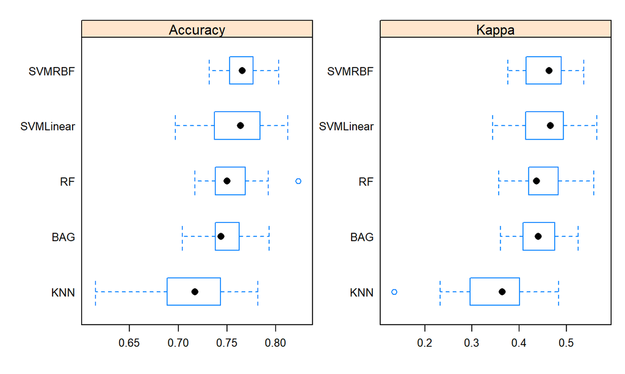

```r
scales <- list(x = list(relation = "free"),
               y = list(relation = "free"))

bwplot(model_comparison, scales = scales)
```